# Biostrings - Intermediate Usage

Kasper D. Hansen

## Dependencies

This document has the following dependencies:

```r
library(Biostrings)
library(BSgenome)
library(BSgenome.Scerevisiae.UCSC.sacCer2)
library(AnnotationHub)
```

Use the following commands to install these packages in R.

```r
source("http://www.bioconductor.org/biocLite.R")
biocLite(c("Biostrings", "BSgenome",
           "BSgenome.Scerevisiae.UCSC.sacCer2", "AnnotationHub"))
```

## Overview

We continue our treatment of *[Biostrings](http://bioconductor.org/packages/release/bioc/html/Biostrings.html)* and *[BSgenome](http://bioconductor.org/packages/release/bioc/html/BSgenome.html)*

## Pattern matching

We often want to find patterns in (long) sequences. *[Biostrings](http://bioconductor.org/packages/release/bioc/html/Biostrings.html)* have a number of functions for doing so

- `matchPattern` and `vmatchPattern`: match a single sequence against one sequence (`matchPattern`) or more than one (`vmatchPattern`) sequences.
- `matchPDict` and `vmatchPDict`: match a (possibly large) set of sequences against one sequence (`matchPDict`) or more than one (`vmatchPDict`) sequences.

These functions allows a small set of mismatches and some small indels. The `Dict` term is used because the function builds a “dictionary” over the sequences.

There are also functions with similar naming using `count` instead of `match` (eg. `countPatterns`). These functions returns the number of matches instead of precise information about where the matches occur.

In many ways, these functions are similar to using short read aligners like Bowtie. But these functions are designed to be comprehensive (return all matches satisfying certain criteria). Having this functionality available in Bioconductor can sometimes be very useful.

```r
dnaseq <- DNAString("ACGTACGT")
matchPattern(dnaseq, Scerevisiae$chrI)
```

```
##   Views on a 230208-letter DNAString subject
## subject: CCACACCACACCCACACACCCACACACCACAC...GTGGGTGTGGTGTGGGTGTGGTGTGTGTGGG
## views:
##     start   end width
## [1] 57932 57939     8 [ACGTACGT]
```

```r
countPattern(dnaseq, Scerevisiae$chrI)
```

```
## [1] 1
```

```r
vmatchPattern(dnaseq, Scerevisiae)
```

```
## GRanges object with 170 ranges and 0 metadata columns:
##         seqnames           ranges strand
##            <Rle>        <IRanges>  <Rle>
##     [1]     chrI [ 57932,  57939]      +
##     [2]     chrI [ 57932,  57939]      -
##     [3]    chrII [ 49581,  49588]      +
##     [4]    chrII [411291, 411298]      +
##     [5]    chrII [491129, 491136]      +
##     ...      ...              ...    ...
##   [166]   chrXVI [195477, 195484]      -
##   [167]   chrXVI [683620, 683627]      -
##   [168]   chrXVI [837296, 837303]      -
##   [169]   chrXVI [906938, 906945]      -
##   [170]   chrXVI [943045, 943052]      -
##   -------
##   seqinfo: 18 sequences from an unspecified genome
```

```r
head(vcountPattern(dnaseq, Scerevisiae))
```

```
##   seqname strand count
## 1    chrI      +     1
## 2    chrI      -     1
## 3   chrII      +     4
## 4   chrII      -     4
## 5  chrIII      +     3
## 6  chrIII      -     3
```

See how we use `vmatchPattern` to examine across all chromosomes.

First, note how the return object of `vmatchPattern` is a `GRanges` given the exact information of where the string matches. Note sequence we search for is its own reverse complement, so we get hits on both strands (which makes sense). Obviously, not all sequences are like this

```r
dnaseq == reverseComplement(dnaseq)
```

```
## [1] TRUE
```

Second, note how the return object of `matchPattern` looks like an `IRanges` but is really something called a `Views`.

## Views

`Views` are used when you have a single big object (think chromosome or other massive dataset) and you need to deal with (many) subsets of this object. `Views` are not restricted to genome sequences; we will discuss `Views` on other types of objects in a different session.

Technically, a `Views` is like an `IRanges` couple with a pointer to the massive object. The `IRanges` contains the indexes. Let’s look at `matchPattern` again:

```r
vi <- matchPattern(dnaseq, Scerevisiae$chrI)
vi
```

```
##   Views on a 230208-letter DNAString subject
## subject: CCACACCACACCCACACACCCACACACCACAC...GTGGGTGTGGTGTGGGTGTGGTGTGTGTGGG
## views:
##     start   end width
## [1] 57932 57939     8 [ACGTACGT]
```

We can get the `IRanges` component by

```r
ranges(vi)
```

```
## IRanges of length 1
##     start   end width
## [1] 57932 57939     8
```

The `IRanges` gives us indexes into the underlying subject (here chromosome I). To be clear, compare these two:

```r
vi
```

```
##   Views on a 230208-letter DNAString subject
## subject: CCACACCACACCCACACACCCACACACCACAC...GTGGGTGTGGTGTGGGTGTGGTGTGTGTGGG
## views:
##     start   end width
## [1] 57932 57939     8 [ACGTACGT]
```

```r
Scerevisiae$chrI[ start(vi):end(vi) ]
```

```
##   8-letter "DNAString" instance
## seq: ACGTACGT
```

The `Views` object also look a bit like a `DNAStringSet`; we can do things like

```r
alphabetFrequency(vi)
```

```
##      A C G T M R W S Y K V H D B N - + .
## [1,] 2 2 2 2 0 0 0 0 0 0 0 0 0 0 0 0 0 0
```

The advantage of `Views` is that they don’t duplicate the sequence information from the subject; all they keep track of are indexes into the subject (stored as `IRanges`). This makes it very (1) fast, (2) low-memory and makes it possible to do things like

```r
shift(vi, 10)
```

```
##   Views on a 230208-letter DNAString subject
## subject: CCACACCACACCCACACACCCACACACCACAC...GTGGGTGTGGTGTGGGTGTGGTGTGTGTGGG
## views:
##     start   end width
## [1] 57942 57949     8 [AAGCTTTG]
```

where we now get the sequence 10 bases next to the original match. This could not be done if all we had were the bases of the original subsequence.

`Views` are especially powerful when there are many of them. A usecase I often have are the set of all exons (or promoters) of all genes in the genome. You can use `GRanges` as `Views` as well. Lets take the hits from `vmatchPattern` above.

```r
gr <- vmatchPattern(dnaseq, Scerevisiae)
vi2 <- Views(Scerevisiae, gr)
```

Now, let us do something with this. First let us get gene coordinates from *[AnnotationHub](http://bioconductor.org/packages/release/bioc/html/AnnotationHub.html)*.

```r
ahub <- AnnotationHub()
qh <- query(ahub, c("sacCer2", "genes"))
qh
```

```
## AnnotationHub with 2 records
## # snapshotDate(): 2015-08-10
## # $dataprovider: UCSC
## # $species: Saccharomyces cerevisiae
## # $rdataclass: GRanges
## # additional mcols(): taxonomyid, genome, description, tags,
## #   sourceurl, sourcetype
## # retrieve records with, e.g., 'object[["AH7048"]]'
##
##            title
##   AH7048 | SGD Genes
##   AH7049 | Ensembl Genes
```

```r
genes <- qh[[which(qh$title == "SGD Genes")]]
genes
```

```
## GRanges object with 6717 ranges and 5 metadata columns:
##          seqnames           ranges strand   |        name     score
##             <Rle>        <IRanges>  <Rle>   | <character> <numeric>
##      [1]     chrI [130802, 131986]      +   |     YAL012W         0
##      [2]     chrI [   335,    649]      +   |     YAL069W         0
##      [3]     chrI [   538,    792]      +   |   YAL068W-A         0
##      [4]     chrI [  1807,   2169]      -   |     YAL068C         0
##      [5]     chrI [  2480,   2707]      +   |   YAL067W-A         0
##      ...      ...              ...    ... ...         ...       ...
##   [6713]  chrXIII [923492, 923800]      -   |     YMR326C         0
##   [6714]  2micron [   252,   1523]      +   |      R0010W         0
##   [6715]  2micron [  1887,   3008]      -   |      R0020C         0
##   [6716]  2micron [  3271,   3816]      +   |      R0030W         0
##   [6717]  2micron [  5308,   6198]      -   |      R0040C         0
##              itemRgb            thick        blocks
##          <character>        <IRanges> <IRangesList>
##      [1]        <NA> [130802, 131986]     [1, 1185]
##      [2]        <NA> [   335,    649]      [1, 315]
##      [3]        <NA> [   538,    792]      [1, 255]
##      [4]        <NA> [  1807,   2169]      [1, 363]
##      [5]        <NA> [  2480,   2707]      [1, 228]
##      ...         ...              ...           ...
##   [6713]        <NA> [923492, 923800]      [1, 309]
##   [6714]        <NA> [   252,   1523]     [1, 1272]
##   [6715]        <NA> [  1887,   3008]     [1, 1122]
##   [6716]        <NA> [  3271,   3816]      [1, 546]
##   [6717]        <NA> [  5308,   6198]      [1, 891]
##   -------
##   seqinfo: 18 sequences from sacCer2 genome
```

Let us compute the GC content of all promoters in the yeast genome.

```r
prom <- promoters(genes)
head(prom, n = 3)
```

```
## GRanges object with 3 ranges and 5 metadata columns:
##       seqnames           ranges strand |        name     score     itemRgb
##          <Rle>        <IRanges>  <Rle> | <character> <numeric> <character>
##   [1]     chrI [128802, 131001]      + |     YAL012W         0        <NA>
##   [2]     chrI [ -1665,    534]      + |     YAL069W         0        <NA>
##   [3]     chrI [ -1462,    737]      + |   YAL068W-A         0        <NA>
##                  thick        blocks
##              <IRanges> <IRangesList>
##   [1] [130802, 131986]     [1, 1185]
##   [2] [   335,    649]      [1, 315]
##   [3] [   538,    792]      [1, 255]
##   -------
##   seqinfo: 18 sequences from sacCer2 genome
```

We get a `warning` that some of these promoters are out-of-band (see the the second and third element in the `prom` object; they have negative values for their ranges). We clean it up and continue

```r
prom <- trim(prom)
promViews <- Views(Scerevisiae, prom)
gcProm <- letterFrequency(promViews, "GC", as.prob = TRUE)
head(gcProm)
```

```
##            G|C
## [1,] 0.4668182
## [2,] 0.4868914
## [3,] 0.4572592
## [4,] 0.3731818
## [5,] 0.3859091
## [6,] 0.3309091
```

In the previous *[Biostrings](http://bioconductor.org/packages/release/bioc/html/Biostrings.html)* session we computed the GC content of the yeast genome. Let us do it again, briefly

```r
params <- new("BSParams", X = Scerevisiae, FUN = letterFrequency, simplify = TRUE)
gccontent <- bsapply(params, letters = "GC")
gcPercentage <- sum(gccontent) / sum(seqlengths(Scerevisiae))
gcPercentage
```

```
## [1] 0.3814872
```

Let us compare this genome percentage to the distribution of GC content for promoters

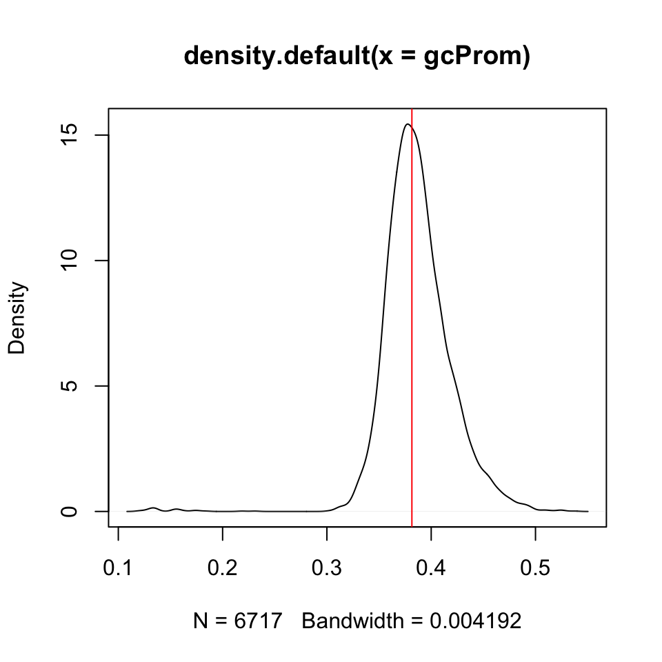

```r
plot(density(gcProm))
abline(v = gcPercentage, col = "red")
```

At first glance, the GC content of the promoters is not very different from the genome-wide GC content (perhaps shifted a bit to the right).

## Specialized alignments

There are a number of other, specialized, alignment functions in *[Biostrings](http://bioconductor.org/packages/release/bioc/html/Biostrings.html)*. They include

- `matchPWM`: a position weight matrix is a common way to represent for example a transcription factor binding motif (think sequence logos). This function allows you to search for such motifs in the genome.
- `pairwiseAlignment`: This function implements pairwise alignments using dynamic programming; providing an interface to both the Smith-Waterman local alignment problem and the Needleman-Wunsch global alignment problems, see a thorough description in (Durbin et al. 1998).
- `trimLRpattern` (trim left-right pattern): Takes a set of sequences and looks for whether they start or end with a given (other sequence), for example a sequencing adapter. Used for trimming reads based on adapter sequences.

For now, we will avoid further discussion of these functions.

One note: `pairwiseAlignment` allows you to do pairwise alignments of millions of short reads against a single sequence, for example a gene or a transposable element. Few people use these algorithms for short read data, because the algorithms scale badly with the length of the sequence (ie. the genome), but they work fine for millions of reads as long as the reference sequence is short. In my opinion this approach might be very fruitful if you are particular interested in high-quality alignments to a specific small gene or region of the genome.

References

Durbin, Richard M, Sean R Eddy, Anders Krogh, Graeme Mitchison, and Sean R Eddy. 1998. *Biological Sequence Analysis: Probabilistic Models of Proteins and Nucleic Acids*. Cambridge University Press.